# project

We think maybe heteroscedasticity is an issue, so we try eye-ball test first.

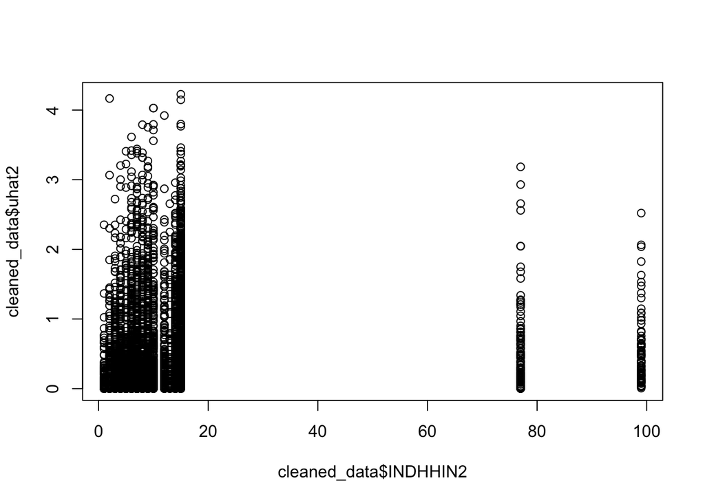

```r
cleaned_data$uhat2 <- regressionpro_ll$residuals^2
plot(cleaned_data$INDHHIN2, cleaned_data$uhat2)
```

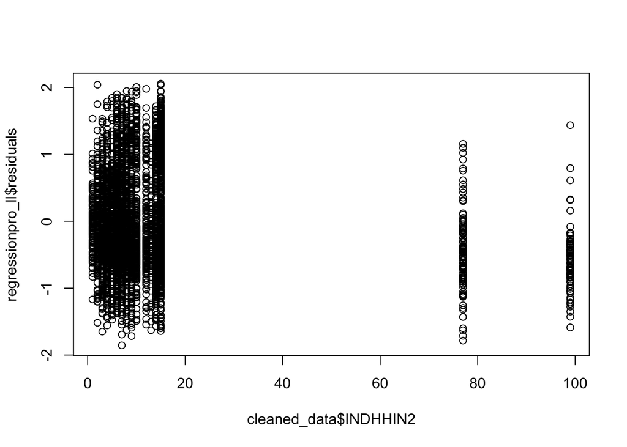

```r
plot(cleaned_data$INDHHIN2, regressionpro_ll$residuals)
```

Yet, we can not know specific result from the tables. So we try park test with income variable.

```r
regression_he <- lm(log(uhat2) ~ log(INDHHIN2), data=cleaned_data[cleaned_data$INDHHIN2>0, ])
summary(regression_he)
```

```
##
## Call:
## lm(formula = log(uhat2) ~ log(INDHHIN2), data = cleaned_data[cleaned_data$INDHHIN2 >
##     0, ])
##
## Residuals:
##      Min       1Q   Median       3Q      Max
## -19.5512  -0.9088   0.4748   1.4745   4.0220
##
## Coefficients:
##               Estimate Std. Error t value Pr(>|t|)
## (Intercept)   -2.97197    0.08913  -33.34   <2e-16 ***
## log(INDHHIN2)  0.54405    0.04012   13.56   <2e-16 ***
## ---
## Signif. codes:  0 '***' 0.001 '**' 0.01 '*' 0.05 '.' 0.1 ' ' 1
##
## Residual standard error: 2.172 on 4954 degrees of freedom
## Multiple R-squared:  0.03579,    Adjusted R-squared:  0.0356
## F-statistic: 183.9 on 1 and 4954 DF,  p-value: < 2.2e-16
```

It shows that t-stat of income variable is around 13.56 and statistically significant. Therefore, it has strong evidence heteroscedasticity.

# Conclusion

In the final project, we build everything from scratch with knowledge we gain from classes. Below are things we learn:

1. Distinguish qualitative and quantitative variable.
2. Use t-test or adjusted R-square to determine if the variable has explanatory power. In other words, should we include the variable.
3. Determine should we use log etc. transformation in the model based on the residuals and t-test values.
4. Know how to tell the variable is intercept dummy and/ or slope dummy.
5. Utilize t-test, f-test, LM-test to see if the variables are statistically significant or jointly significant.
6. Use eye-ball test, park test etc. to take a look if heteroscedasticity is an issue in the model.

I think there is one more important thing I learn from doing this project. That is, knowing what problem we want to solve before we clean and create the data set. The reason is that when I did this project, I revised several times to build the appropriate data set back and forth since I did not think thoroughly. So, I think if I knew what questions I would tackle then I could save a lot of time to create the proper data set.

data source: https://wwwn.cdc.gov/nchs/nhanes/search/DataPage.aspx?Component=Demographics&CycleBeginYear=2015

reference: https://www.cdc.gov/nchs/products/databriefs/db303.htm